# Practice 6

Ur_group8

2021 7 2

1. 미세먼지 농도(pm2.5)를 예측하는 Single Variable 모델을 만들어보려고 한다.  
   가장 먼저 train과 test 데이터의 타입을 확인해보자. 또한 train과 test 데이터에서 NA가 얼마나 있는지 확인하고,주로 몰려있는 날짜나 기간이 있는지 확인하여보자.  
   pm2.5는 목적변수이므로 NA가 허용되지 않는다. 이를 삭제해보자.

```r
PRSA_data <- load("data/PRSA_data.RData")
library("tidyr")
library("dplyr")
glimpse(test_data)
```

```
## Rows: 8,760
## Columns: 6
## $ No    <dbl> 35065, 35066, 35067, 35068, 35069, 35070, 35071, 35072, 35073, 3…
## $ Month <fct> Jan, Jan, Jan, Jan, Jan, Jan, Jan, Jan, Jan, Jan, Jan, Jan, Jan,…
## $ TEMP  <dbl> 7, 7, 6, 6, 3, 4, 6, 6, 6, 7, 8, 9, 10, 11, 11, 11, 11, 10, 9, 9…
## $ Iws   <dbl> 143.48, 147.50, 151.52, 153.31, 0.89, 4.02, 8.94, 16.09, 21.90, …
## $ time  <fct> night, night, night, night, night, night, night, night, night, n…
## $ pm2.5 <fct> LOW, LOW, LOW, LOW, HIGH, HIGH, HIGH, HIGH, LOW, LOW, LOW, LOW, …
```

```r
glimpse(train_data)
```

```
## Rows: 35,064
## Columns: 6
## $ No    <dbl> 1, 2, 3, 4, 5, 6, 7, 8, 9, 10, 11, 12, 13, 14, 15, 16, 17, 18, 1…
## $ Month <fct> Jan, Jan, Jan, Jan, Jan, Jan, Jan, Jan, Jan, Jan, Jan, Jan, Jan,…
## $ TEMP  <dbl> -11, -12, -11, -14, -12, -10, -9, -9, -9, -8, -7, -5, -5, -3, -2…
## $ Iws   <dbl> 1.79, 4.92, 6.71, 9.84, 12.97, 16.10, 19.23, 21.02, 24.15, 27.28…
## $ time  <fct> night, night, night, night, night, night, night, night, night, n…
## $ pm2.5 <fct> NA, NA, NA, NA, NA, NA, NA, NA, NA, NA, NA, NA, NA, NA, NA, NA, …
```

```r
colSums(is.na(train_data))
```

```
##    No Month  TEMP   Iws  time pm2.5
##     0     0     0     0     0  1968
```

```r
colSums(is.na(test_data))
```

```
##    No Month  TEMP   Iws  time pm2.5
##     0     0     0     0     0    99
```

RData 파일을 load로 불러오고 필요한 library 패키지를 설정해놨다. 이후 train과 test에서 na 데이터가 위치한 변수는 미세먼지농도(pm2.5) 변수에서 나타나는 것으로 확인되었다.

추가로 월별로 NA값이 몇개 있는지 table로 확인하여 어느 월에 특히 많이 분포했는지 확인하였다.

```r
train_month <- subset(train_data, is.na(train_data$pm2.5))
test_month<-subset(test_data, is.na(test_data$pm2.5))
table(train_month$Month)
```

```
##
## Apr Aug Dec Feb Jan Jul Jun Mar May Nov Oct Sep
## 192 372 151   8 242  66 178 163 109  85 140 262
```

```r
table(test_month$Month)
```

```
##
## Apr Aug Dec Feb Jan Jul Jun Mar May Nov Oct Sep
##   3  11  28   3   7   7  17   1   2  14   1   5
```

pm2.5를 예측하는 값으로 활용하기 위해서 NA값을 모두 지우도록 한다.

```r
train_data <- na.omit(train_data)
test_data <- na.omit(test_data)
```

2.1 Month 변수를 활용하여 pm2.5를 예측하는 Single Variable 모델을 만들어보자. 이때 Threshold는 0.5로 설정하도록 하자.또한 이 모델의 정확도(Accuracy)을 train과 test 데이터에서 계산해보도록 하자. • 일반적으로 예측 모형에서 예측 대상이 되는 (관심대상인) class의 sample을 positive sample로 간주합니다. 여기에서는 미세먼지가 나쁨인 pm2.5 = HIGH인 경우를 positive(TRUE) sample로 보고 문제를 풀어봅시다.

```r
tble <- table(train_data$Month, train_data$pm2.5)
tble
```

```
##
##       HIGH  LOW
##   Apr 1177 1511
##   Aug 1290 1314
##   Dec 1251 1574
##   Feb 1401 1303
##   Jan 1189 1545
##   Jul 1545 1365
##   Jun 1680 1022
##   Mar 1299 1514
##   May 1353 1514
##   Nov 1371 1424
##   Oct 1414 1422
##   Sep 1275 1343
```

```r
prop.table(tble, margin =1)
```

```
##
##            HIGH       LOW
##   Apr 0.4378720 0.5621280
##   Aug 0.4953917 0.5046083
##   Dec 0.4428319 0.5571681
##   Feb 0.5181213 0.4818787
##   Jan 0.4348939 0.5651061
##   Jul 0.5309278 0.4690722
##   Jun 0.6217617 0.3782383
##   Mar 0.4617846 0.5382154
##   May 0.4719219 0.5280781
##   Nov 0.4905188 0.5094812
##   Oct 0.4985896 0.5014104
##   Sep 0.4870130 0.5129870
```

table을 활용해서 월별로 미세먼지농도의 HIGH, LOW로 측정된 총값을 비교해보고 해당 값으로  
prop.table을 활용해 table의 값을 행 기준인 월단위로 HIGH와 LOW의 비율을 확인 할 수 있도록 했다.

```r
train.model <- prop.table(tble, margin = 1)[,1]
sort(train.model, decreasing =  T)
```

```
##       Jun       Jul       Feb       Oct       Aug       Nov       Sep       May
## 0.6217617 0.5309278 0.5181213 0.4985896 0.4953917 0.4905188 0.4870130 0.4719219
##       Mar       Dec       Apr       Jan
## 0.4617846 0.4428319 0.4378720 0.4348939
```

prop.table에서 HIGH값을 나온 비율을 positive sample로 보고 문제를 풀기 위해 HIGH(1행)만 선택해 train.model로 설정했다.  
이후 나온 모델의 값들을 내림차순으로 확인해서 6월,7월,2월의 미세먼지 수치 나쁨 비율이 가장 높은 것을 확인 할 수 있었다.

```r
train_data$est_prob <- train.model[train_data$Month]
threshold <- 0.5

train_data$prediction <- train_data$est_prob >threshold

conf.table <- table(pred = train_data$prediction, actual = train_data$pm2.5)
conf.table
```

```
##        actual
## pred     HIGH   LOW
##   FALSE 11619 13161
##   TRUE   4626  3690
```

```r
accuracy <- round(sum(conf.table[1,2]+ conf.table[2.1]) / sum(conf.table),2)
accuracy
```

```
## [1] 0.54
```

모델 값을 확인 했으니 이제는 train 데이터에서 월별로 미세먼지 수치 나쁨 확률(train_data$est_prob)을 확인 해볼 차례다.  
threshold를 0.5로 설정 한 후 모델의 정확도(Accuracy)를 계산하기 위해 conf.table 테이블을 만들었다. conf.table은 미세먼지 나쁨 확률 예측값과 실제 나쁨으로 나온 값을 비교한다. 여기서 HIGH를 true값으로 Accuracy(정확도)를 계산하기로 했기 때문에  
conf.table의 총값 중 HIGH-TRUE(4626)와 LOW-FALSE(13161)값을 더한값의 비율을 확인한다.  
확인한 결과 train_data의 Accuracy는 0.54이다.

아래는 같은 방법으로 test_data의 Accuracy를 확인해보았다.

```r
test_data$est.prop<-train.model[test_data$Month]
head(test_data,10)
```

```
## # A tibble: 10 x 7
##       No Month  TEMP    Iws time  pm2.5 est.prop
##    <dbl> <fct> <dbl>  <dbl> <fct> <fct>    <dbl>
##  1 35065 Jan       7 143.   night LOW      0.435
##  2 35066 Jan       7 148.   night LOW      0.435
##  3 35067 Jan       6 152.   night LOW      0.435
##  4 35068 Jan       6 153.   night LOW      0.435
##  5 35069 Jan       3   0.89 night HIGH     0.435
##  6 35070 Jan       4   4.02 night HIGH     0.435
##  7 35071 Jan       6   8.94 night HIGH     0.435
##  8 35072 Jan       6  16.1  night HIGH     0.435
##  9 35073 Jan       6  21.9  night LOW      0.435
## 10 35074 Jan       7  26.8  night LOW      0.435
```

```r
test_data$predict<-test_data$est.prop>threshold
head(test_data,10)
```

```
## # A tibble: 10 x 8
##       No Month  TEMP    Iws time  pm2.5 est.prop predict
##    <dbl> <fct> <dbl>  <dbl> <fct> <fct>    <dbl> <lgl>
##  1 35065 Jan       7 143.   night LOW      0.435 FALSE
##  2 35066 Jan       7 148.   night LOW      0.435 FALSE
##  3 35067 Jan       6 152.   night LOW      0.435 FALSE
##  4 35068 Jan       6 153.   night LOW      0.435 FALSE
##  5 35069 Jan       3   0.89 night HIGH     0.435 FALSE
##  6 35070 Jan       4   4.02 night HIGH     0.435 FALSE
##  7 35071 Jan       6   8.94 night HIGH     0.435 FALSE
##  8 35072 Jan       6  16.1  night HIGH     0.435 FALSE
##  9 35073 Jan       6  21.9  night LOW      0.435 FALSE
## 10 35074 Jan       7  26.8  night LOW      0.435 FALSE
```

이쯤에서 test_data의 예측하는 비율(est.prop)이라는 새로운 변수를 만들고 변수값은 위에서 만든 모델값을 월별로 나오도록 설정한다.  
첫행 10줄을 확인해보면 원데이터프래임에서 새로운 열 2개가 생겼고 threshold(0.5)보다 낮게 나온 1월의 예측 비율은 모두 예측변수에서 FALSE로 처리가 됨을 볼 수 있다.

```r
conf.table_test<-table(pred=test_data$predict,actual=test_data$pm2.5)
conf.table_test
```

```
##        actual
## pred    HIGH  LOW
##   FALSE 3168 3384
##   TRUE  1035 1074
```

```r
accuracy_test<-round((conf.table_test[1,2]+conf.table_test[2,1])/sum(conf.table_test),2)
accuracy_test
```

```
## [1] 0.51
```

확인한 결과 test_data의 Accuracy는 0.51이다.

아래는 train과 test의 precision과 recall을 한번에 볼 수 있도록 한 테이블이다. precision은 미세먼지가 high로 나올 확률값을 나타내고 recall은 실제 미세먼지가 high로 나온 값의 비율이다.

```r
precision<-conf.table[2,1]/sum(conf.table[2,])
recall<-conf.table[2,1]/sum(conf.table[,1])
precision_test<-conf.table_test[2,1]/sum(conf.table_test[2,])
recall_test<-conf.table_test[2,1]/sum(conf.table_test[,1])

train_pre.recall<-cbind(precision,recall)
test_pre.recall<-cbind(precision_test,recall_test)
rbind(train_pre.recall,test_pre.recall)
```

```
##      precision    recall
## [1,] 0.5562771 0.2847645
## [2,] 0.4907539 0.2462527
```

2.2 문제 2-1에서 구한 모델의 AUC를 train과 test 데이터 각각에 대해서 계산해보고, ROC 커브를 그려보자.

```r
library(ROCR)

calAUC<-function(predCol, targetCol){
  perf<-performance(prediction(predCol,targetCol),'auc')
  as.numeric(perf@y.values)
}
```

ROC커브와 AUC값을 구하기 위해서는 ROCR 패키지를 설치해야 한다.  
AUC값을 구하기 위해 calAUC 계산식을 인터넷에서 찾아와 사용하였다.

```r
AUC_train<-calAUC(train_data$est_prob,train_data$pm2.5)
plot(performance(prediction(train_data$est_prob,train_data$pm2.5),'tpr','fpr'))
```

[output not shown]

```r
AUC_test<-calAUC(test_data$est.prop,test_data$pm2.5)
plot(performance(prediction(test_data$est.prop,test_data$pm2.5),'tpr','fpr'))
```

[output not shown]

```r
print(paste("AUC value  for train data", round(AUC_train, 2)))
```

```
## [1] "AUC value  for train data 0.45"
```

```r
print(paste("AUC value  for test data", round(AUC_test, 2)))
```

```
## [1] "AUC value  for test data 0.52"
```

train AUC 수치는 0.45, test AUC는 0.52로 test가 더 높다.

2.4 문제 2-1에서 구한 모델의 threshold를 바꿔가면서 precision과 recall 값의 변화를 확인해보자.  
**threshold가 0.45일 때**

```r
threshold <- 0.45
train_data$prediction <- train_data$est_prob >threshold

conf.table <- table(pred = train_data$prediction, actual = train_data$pm2.5)
accuracy <- round(sum(conf.table[1,2]+ conf.table[2.1]) / sum(conf.table),2)


test.model<-prop.table(table(test_data$Month,test_data$pm2.5),1)[,1]
test_data$est.prop<-train.model[test_data$Month]
head(test_data,10)
```

```
## # A tibble: 10 x 8
##       No Month  TEMP    Iws time  pm2.5 est.prop predict
##    <dbl> <fct> <dbl>  <dbl> <fct> <fct>    <dbl> <lgl>
##  1 35065 Jan       7 143.   night LOW      0.435 FALSE
##  2 35066 Jan       7 148.   night LOW      0.435 FALSE
##  3 35067 Jan       6 152.   night LOW      0.435 FALSE
##  4 35068 Jan       6 153.   night LOW      0.435 FALSE
##  5 35069 Jan       3   0.89 night HIGH     0.435 FALSE
##  6 35070 Jan       4   4.02 night HIGH     0.435 FALSE
##  7 35071 Jan       6   8.94 night HIGH     0.435 FALSE
##  8 35072 Jan       6  16.1  night HIGH     0.435 FALSE
##  9 35073 Jan       6  21.9  night LOW      0.435 FALSE
## 10 35074 Jan       7  26.8  night LOW      0.435 FALSE
```

```r
test_data$predict<-test_data$est.prop>threshold
head(test_data,10)
```

```
## # A tibble: 10 x 8
##       No Month  TEMP    Iws time  pm2.5 est.prop predict
##    <dbl> <fct> <dbl>  <dbl> <fct> <fct>    <dbl> <lgl>
##  1 35065 Jan       7 143.   night LOW      0.435 FALSE
##  2 35066 Jan       7 148.   night LOW      0.435 FALSE
##  3 35067 Jan       6 152.   night LOW      0.435 FALSE
##  4 35068 Jan       6 153.   night LOW      0.435 FALSE
##  5 35069 Jan       3   0.89 night HIGH     0.435 FALSE
##  6 35070 Jan       4   4.02 night HIGH     0.435 FALSE
##  7 35071 Jan       6   8.94 night HIGH     0.435 FALSE
##  8 35072 Jan       6  16.1  night HIGH     0.435 FALSE
##  9 35073 Jan       6  21.9  night LOW      0.435 FALSE
## 10 35074 Jan       7  26.8  night LOW      0.435 FALSE
```

```r
conf.table_test<-table(pred=test_data$predict,actual=test_data$pm2.5)
conf.table_test
```

```
##        actual
## pred    HIGH  LOW
##   FALSE 1099 1071
##   TRUE  3104 3387
```

```r
accuracy_test<-round((conf.table_test[1,2]+conf.table_test[2,1])/sum(conf.table_test),2)
accuracy_test
```

```
## [1] 0.48
```

```r
calAUC <- function(predCol, targetCol){
  perf <- performance(prediction(predCol,targetCol),'auc')
  as.numeric(perf@y.values)
}

AUC.train <- calAUC(train_data$est_prob, train_data$pm2.5 == "HIGH")
AUC.test <- calAUC(test_data$est.prop, test_data$pm2.5 == "HIGH")

print(paste("AUC value  for train data", round(AUC.train, 2)))
```

```
## [1] "AUC value  for train data 0.55"
```

```r
plot(performance(prediction(train_data$est_prob,train_data$pm2.5),'tpr','fpr'))
```

```r
print(paste("AUC value  for test data", round(AUC.test, 2)))
```

```
## [1] "AUC value  for test data 0.48"
```

```r
plot(performance(prediction(test_data$est.prop,test_data$pm2.5),'tpr','fpr'))
```

```r
precision <- conf.table[2,1] / sum(conf.table[2,])
recall <- conf.table[2,1] / sum(conf.table[,1])

precision.t <- conf.table_test[2,1] / sum(conf.table_test[2,])
recall.t <- conf.table_test[2,1] / sum(conf.table_test[,1])
```

threshold가 0.45일 때 나오는 precision과 recall 값은 아래와 같다.

precision 0.5081895  
recall 0.7773469  
precision.t 0.4782006  
recall.t 0.7385201

**threshold가 0.55일 때**

```r
threshold <- 0.55
train_data$prediction <- train_data$est_prob >threshold

conf.table <- table(pred = train_data$prediction, actual = train_data$pm2.5)
accuracy <- round(sum(conf.table[1,2]+ conf.table[2.1]) / sum(conf.table),2)


test.model<-prop.table(table(test_data$Month,test_data$pm2.5),1)[,1]
test_data$est.prop<-train.model[test_data$Month]
head(test_data,10)
```

```
## # A tibble: 10 x 8
##       No Month  TEMP    Iws time  pm2.5 est.prop predict
##    <dbl> <fct> <dbl>  <dbl> <fct> <fct>    <dbl> <lgl>
##  1 35065 Jan       7 143.   night LOW      0.435 FALSE
##  2 35066 Jan       7 148.   night LOW      0.435 FALSE
##  3 35067 Jan       6 152.   night LOW      0.435 FALSE
##  4 35068 Jan       6 153.   night LOW      0.435 FALSE
##  5 35069 Jan       3   0.89 night HIGH     0.435 FALSE
##  6 35070 Jan       4   4.02 night HIGH     0.435 FALSE
##  7 35071 Jan       6   8.94 night HIGH     0.435 FALSE
##  8 35072 Jan       6  16.1  night HIGH     0.435 FALSE
##  9 35073 Jan       6  21.9  night LOW      0.435 FALSE
## 10 35074 Jan       7  26.8  night LOW      0.435 FALSE
```

```r
test_data$predict<-test_data$est.prop>threshold
head(test_data,10)
```

```
## # A tibble: 10 x 8
##       No Month  TEMP    Iws time  pm2.5 est.prop predict
##    <dbl> <fct> <dbl>  <dbl> <fct> <fct>    <dbl> <lgl>
##  1 35065 Jan       7 143.   night LOW      0.435 FALSE
##  2 35066 Jan       7 148.   night LOW      0.435 FALSE
##  3 35067 Jan       6 152.   night LOW      0.435 FALSE
##  4 35068 Jan       6 153.   night LOW      0.435 FALSE
##  5 35069 Jan       3   0.89 night HIGH     0.435 FALSE
##  6 35070 Jan       4   4.02 night HIGH     0.435 FALSE
##  7 35071 Jan       6   8.94 night HIGH     0.435 FALSE
##  8 35072 Jan       6  16.1  night HIGH     0.435 FALSE
##  9 35073 Jan       6  21.9  night LOW      0.435 FALSE
## 10 35074 Jan       7  26.8  night LOW      0.435 FALSE
```

```r
conf.table_test<-table(pred=test_data$predict,actual=test_data$pm2.5)
conf.table_test
```

```
##        actual
## pred    HIGH  LOW
##   FALSE 4004 3954
##   TRUE   199  504
```

```r
accuracy_test<-round((conf.table_test[1,2]+conf.table_test[2,1])/sum(conf.table_test),2)
accuracy_test
```

```
## [1] 0.48
```

```r
calAUC <- function(predCol, targetCol){
  perf <- performance(prediction(predCol,targetCol),'auc')
  as.numeric(perf@y.values)
}

AUC.train <- calAUC(train_data$est_prob, train_data$pm2.5 == "HIGH")
AUC.test <- calAUC(test_data$est.prop, test_data$pm2.5 == "HIGH")

print(paste("AUC value  for train data", round(AUC.train, 2)))
```

```
## [1] "AUC value  for train data 0.55"
```

```r
plot(performance(prediction(train_data$est_prob,train_data$pm2.5),'tpr','fpr'))
```

```r
print(paste("AUC value  for test data", round(AUC.test, 2)))
```

```
## [1] "AUC value  for test data 0.48"
```

```r
plot(performance(prediction(test_data$est.prop,test_data$pm2.5),'tpr','fpr'))
```

```r
precision <- conf.table[2,1] / sum(conf.table[2,])
recall <- conf.table[2,1] / sum(conf.table[,1])

precision.t <- conf.table_test[2,1] / sum(conf.table_test[2,])
recall.t <- conf.table_test[2,1] / sum(conf.table_test[,1])
```

precision 0.6217617  
recall 0.1034164  
precision.t 0.2830725  
recall.t 0.04734713

2.5 문제 2-4에서 나온 결과를 바탕으로 threshold를 어떻게 설정하는 것이 좋을지 생각해보고, 그 이유와 함께 설명해보자.

| 항목 | threshold 0.45 | threshold 0.5 | threshold 0.55 |
| --- | --- | --- | --- |
| precision | 0.5081895 | 0.5562771 | 0.6217617 |
| recall | 0.7773469 | 0.2847645 | 0.1034164 |
| precision.t | 0.4782006 | 0.4907539 | 0.2830725 |
| recall.t | 0.7385201 | 0.2462527 | 0.04734713 |

0.55를 할 경우 train과 test의 precision과 recall 값의 차이가 크므로 정확하다고 보기에는 힘들다.

따라서 recall이 precision보다 낮지만 비교적 train 과 test 값들이 비슷한 수준인 0.5 threshold를 선택하는것이 괜찮다고 보인다.

2.6 Trade-off 관계에 있는 precision과 recall을 하나의 measure로 보기 위해서 F1 Score라는 것을 사용하기도 한다.  
문제 2-4에서 선정한 threshold를 기준으로 F1 score를 계산해보자. F1 score는 아래 식과 같이 계산한다

```r
F1.train <- 2 * precision * recall / (precision + recall)
F1.test <- 2 * precision.t * recall.t / (precision.t + recall.t)
```

```r
train_data$TEMP_GRP <- cut(train_data$TEMP, breaks = c(-19, 0, 10, 20, 30, 41), include.lowest = T)
levels(train_data$TEMP_GRP)<-c('Very cold', 'cold', 'cool', 'hot', 'Very hot')
```

```r
tble2 <- table(train_data$TEMP_GRP, train_data$pm2.5)
tble2
```

```
##
##             HIGH  LOW
##   Very cold 3743 4044
##   cold      3148 3892
##   cool      3583 3928
##   hot       5212 4202
##   Very hot   559  785
```

TEMP_GRP의 pm2.5 값을 계산하기 위한 식은 echo=false로 보이지 않도록 하고 accuracy 값만 보이도록 설정하였다

```
##
##                  HIGH       LOW
##   Very cold 0.4806729 0.5193271
##   cold      0.4471591 0.5528409
##   cool      0.4770337 0.5229663
##   hot       0.5536435 0.4463565
##   Very hot  0.4159226 0.5840774
```

```
##       hot Very cold      cool      cold  Very hot
## 0.5536435 0.4806729 0.4770337 0.4471591 0.4159226
```

```
##        actual
## pred     HIGH   LOW
##   FALSE 11033 12649
##   TRUE   5212  4202
```

```
## [1] 0.54
```

```
## # A tibble: 10 x 10
##       No Month  TEMP    Iws time  pm2.5 est.prop predict TEMP_GRP est.prop2
##    <dbl> <fct> <dbl>  <dbl> <fct> <fct>    <dbl> <lgl>   <fct>        <dbl>
##  1 35065 Jan       7 143.   night LOW      0.435 FALSE   cold         0.447
##  2 35066 Jan       7 148.   night LOW      0.435 FALSE   cold         0.447
##  3 35067 Jan       6 152.   night LOW      0.435 FALSE   cold         0.447
##  4 35068 Jan       6 153.   night LOW      0.435 FALSE   cold         0.447
##  5 35069 Jan       3   0.89 night HIGH     0.435 FALSE   cold         0.447
##  6 35070 Jan       4   4.02 night HIGH     0.435 FALSE   cold         0.447
##  7 35071 Jan       6   8.94 night HIGH     0.435 FALSE   cold         0.447
##  8 35072 Jan       6  16.1  night HIGH     0.435 FALSE   cold         0.447
##  9 35073 Jan       6  21.9  night LOW      0.435 FALSE   cold         0.447
## 10 35074 Jan       7  26.8  night LOW      0.435 FALSE   cold         0.447
```

```
## # A tibble: 10 x 11
##       No Month  TEMP    Iws time  pm2.5 est.prop predict TEMP_GRP est.prop2
##    <dbl> <fct> <dbl>  <dbl> <fct> <fct>    <dbl> <lgl>   <fct>        <dbl>
##  1 35065 Jan       7 143.   night LOW      0.435 FALSE   cold         0.447
##  2 35066 Jan       7 148.   night LOW      0.435 FALSE   cold         0.447
##  3 35067 Jan       6 152.   night LOW      0.435 FALSE   cold         0.447
##  4 35068 Jan       6 153.   night LOW      0.435 FALSE   cold         0.447
##  5 35069 Jan       3   0.89 night HIGH     0.435 FALSE   cold         0.447
##  6 35070 Jan       4   4.02 night HIGH     0.435 FALSE   cold         0.447
##  7 35071 Jan       6   8.94 night HIGH     0.435 FALSE   cold         0.447
##  8 35072 Jan       6  16.1  night HIGH     0.435 FALSE   cold         0.447
##  9 35073 Jan       6  21.9  night LOW      0.435 FALSE   cold         0.447
## 10 35074 Jan       7  26.8  night LOW      0.435 FALSE   cold         0.447
## # … with 1 more variable: predict2 <lgl>
```

```
##        actual
## pred    HIGH  LOW
##   FALSE 3056 3196
##   TRUE  1147 1261
```

```
## [1] 0.5
```

온도의 train accuracy2는 0.54, accuracy_test2는 0.5이다.

AUC값을 계산하던 중 test_data$TEMP_GRP에 NA값이 있는 것을 확인하여 na.omit로 NA값을 제거하고 AUC값을 계속 구해주었다.

```r
train_data <- na.omit(train_data)
test_data <- na.omit(test_data)

AUC.train2 <- calAUC(train_data$est_prob2, train_data$pm2.5 == "HIGH")
AUC.test2 <- calAUC(test_data$est.prop2, test_data$pm2.5 == "HIGH")

colSums(is.na(test_data))
```

```
##        No     Month      TEMP       Iws      time     pm2.5  est.prop   predict
##         0         0         0         0         0         0         0         0
##  TEMP_GRP est.prop2  predict2
##         0         0         0
```

```r
test_data <- na.omit(test_data)
AUC.test2 <- calAUC(test_data$est.prop2, test_data$pm2.5 == "HIGH")

print(paste("AUC value  for train data", round(AUC.train2, 2)))
```

```
## [1] "AUC value  for train data 0.55"
```

```r
plot(performance(prediction(train_data$est_prob2,train_data$pm2.5),'tpr','fpr'))
```

```r
print(paste("AUC value  for test data", round(AUC.test2, 2)))
```

```
## [1] "AUC value  for test data 0.53"
```

```r
plot(performance(prediction(test_data$est.prop2,test_data$pm2.5),'tpr','fpr'))
```

TEMP의 AUC값은 아래와 같다.  
AUC value for train data 0.55  
AUC value for test data 0.53

3-3  
Threshold 0.5를 기준으로 train AUC가 0.55로 test AUC 0.53보다 크니까 overfitting이라고 할 수 있다.

```r
 # threshold가 0.45일 때
threshold <- 0.45
train_data$prediction2 <- train_data$est_prob2 > threshold

conf.table2 <- table(pred = train_data$prediction2, actual = train_data$pm2.5)
conf.table2
```

```
##        actual
## pred     HIGH   LOW
##   FALSE  3707  4677
##   TRUE  12538 12174
```

```r
accuracy2 <- round(sum(conf.table2[1,2]+ conf.table2[2.1]) / sum(conf.table2),2)
accuracy2
```

```
## [1] 0.52
```

```r
test_data$TEMP_GRP <- cut(test_data$TEMP, breaks = c(-19, 0, 10, 20, 30, 42), include.lowest = T)
levels(test_data$TEMP_GRP)<-c('Very cold', 'cold', 'cool', 'hot', 'Very hot')
test.model2 <- prop.table(table(test_data$TEMP_GRP, test_data$pm2.5),1)[,1]
test_data$est.prop2 <- train.model2[test_data$TEMP_GRP]
head(test_data,10)
```

```
## # A tibble: 10 x 11
##       No Month  TEMP    Iws time  pm2.5 est.prop predict TEMP_GRP est.prop2
##    <dbl> <fct> <dbl>  <dbl> <fct> <fct>    <dbl> <lgl>   <fct>        <dbl>
##  1 35065 Jan       7 143.   night LOW      0.435 FALSE   cold         0.447
##  2 35066 Jan       7 148.   night LOW      0.435 FALSE   cold         0.447
##  3 35067 Jan       6 152.   night LOW      0.435 FALSE   cold         0.447
##  4 35068 Jan       6 153.   night LOW      0.435 FALSE   cold         0.447
##  5 35069 Jan       3   0.89 night HIGH     0.435 FALSE   cold         0.447
##  6 35070 Jan       4   4.02 night HIGH     0.435 FALSE   cold         0.447
##  7 35071 Jan       6   8.94 night HIGH     0.435 FALSE   cold         0.447
##  8 35072 Jan       6  16.1  night HIGH     0.435 FALSE   cold         0.447
##  9 35073 Jan       6  21.9  night LOW      0.435 FALSE   cold         0.447
## 10 35074 Jan       7  26.8  night LOW      0.435 FALSE   cold         0.447
## # … with 1 more variable: predict2 <lgl>
```

```r
test_data$predict2 <- test_data$est.prop2 > threshold
head(test_data,10)
```

```
## # A tibble: 10 x 11
##       No Month  TEMP    Iws time  pm2.5 est.prop predict TEMP_GRP est.prop2
##    <dbl> <fct> <dbl>  <dbl> <fct> <fct>    <dbl> <lgl>   <fct>        <dbl>
##  1 35065 Jan       7 143.   night LOW      0.435 FALSE   cold         0.447
##  2 35066 Jan       7 148.   night LOW      0.435 FALSE   cold         0.447
##  3 35067 Jan       6 152.   night LOW      0.435 FALSE   cold         0.447
##  4 35068 Jan       6 153.   night LOW      0.435 FALSE   cold         0.447
##  5 35069 Jan       3   0.89 night HIGH     0.435 FALSE   cold         0.447
##  6 35070 Jan       4   4.02 night HIGH     0.435 FALSE   cold         0.447
##  7 35071 Jan       6   8.94 night HIGH     0.435 FALSE   cold         0.447
##  8 35072 Jan       6  16.1  night HIGH     0.435 FALSE   cold         0.447
##  9 35073 Jan       6  21.9  night LOW      0.435 FALSE   cold         0.447
## 10 35074 Jan       7  26.8  night LOW      0.435 FALSE   cold         0.447
## # … with 1 more variable: predict2 <lgl>
```

```r
conf.table_test2 <- table(pred=test_data$predict2,actual=test_data$pm2.5)
conf.table_test2
```

```
##        actual
## pred    HIGH  LOW
##   FALSE 1063 1313
##   TRUE  3140 3144
```

```r
accuracy_test2 <-round((conf.table_test2[1,2]+conf.table_test2[2,1])/sum(conf.table_test2),2)
accuracy_test2
```

```
## [1] 0.51
```

```r
calAUC <- function(predCol, targetCol){
  perf <- performance(prediction(predCol,targetCol),'auc')
  as.numeric(perf@y.values)
}

AUC.train2 <- calAUC(train_data$est_prob2, train_data$pm2.5 == "HIGH")
AUC.test2 <- calAUC(test_data$est.prop2, test_data$pm2.5 == "HIGH")

print(paste("AUC value  for train data", round(AUC.train2, 2)))
```

```
## [1] "AUC value  for train data 0.55"
```

```r
plot(performance(prediction(train_data$est_prob2,train_data$pm2.5),'tpr','fpr'))
```

```r
print(paste("AUC value  for test data", round(AUC.test2, 2)))
```

```
## [1] "AUC value  for test data 0.53"
```

```r
plot(performance(prediction(test_data$est.prop2,test_data$pm2.5),'tpr','fpr'))
```

```r
precision2 <- conf.table2[2,1] / sum(conf.table2[2,])
recall2 <- conf.table2[2,1] / sum(conf.table2[,1])

precision.t2 <- conf.table_test2[2,1] / sum(conf.table_test2[2,])
recall.t2 <- conf.table_test2[2,1] / sum(conf.table_test2[,1])

precision2
```

```
## [1] 0.5073648
```

```r
recall2
```

```
## [1] 0.7718067
```

```r
precision.t2
```

```
## [1] 0.4996817
```

```r
recall.t2
```

```
## [1] 0.7470854
```

```r
 # threshold가 0.48일 때
threshold <- 0.48
train_data$prediction2 <- train_data$est_prob2 > threshold

conf.table2 <- table(pred = train_data$prediction2, actual = train_data$pm2.5)
conf.table2
```

```
##        actual
## pred    HIGH  LOW
##   FALSE 7290 8605
##   TRUE  8955 8246
```

```r
accuracy2 <- round(sum(conf.table2[1,2]+ conf.table2[2.1]) / sum(conf.table2),2)
accuracy2
```

```
## [1] 0.53
```

```r
test_data$TEMP_GRP <- cut(test_data$TEMP, breaks = c(-19, 0, 10, 20, 30, 42), include.lowest = T)
levels(test_data$TEMP_GRP)<-c('Very cold', 'cold', 'cool', 'hot', 'Very hot')
test.model2 <- prop.table(table(test_data$TEMP_GRP, test_data$pm2.5),1)[,1]
test_data$est.prop2 <- train.model2[test_data$TEMP_GRP]
head(test_data,10)
```

```
## # A tibble: 10 x 11
##       No Month  TEMP    Iws time  pm2.5 est.prop predict TEMP_GRP est.prop2
##    <dbl> <fct> <dbl>  <dbl> <fct> <fct>    <dbl> <lgl>   <fct>        <dbl>
##  1 35065 Jan       7 143.   night LOW      0.435 FALSE   cold         0.447
##  2 35066 Jan       7 148.   night LOW      0.435 FALSE   cold         0.447
##  3 35067 Jan       6 152.   night LOW      0.435 FALSE   cold         0.447
##  4 35068 Jan       6 153.   night LOW      0.435 FALSE   cold         0.447
##  5 35069 Jan       3   0.89 night HIGH     0.435 FALSE   cold         0.447
##  6 35070 Jan       4   4.02 night HIGH     0.435 FALSE   cold         0.447
##  7 35071 Jan       6   8.94 night HIGH     0.435 FALSE   cold         0.447
##  8 35072 Jan       6  16.1  night HIGH     0.435 FALSE   cold         0.447
##  9 35073 Jan       6  21.9  night LOW      0.435 FALSE   cold         0.447
## 10 35074 Jan       7  26.8  night LOW      0.435 FALSE   cold         0.447
## # … with 1 more variable: predict2 <lgl>
```

```r
test_data$predict2 <- test_data$est.prop2 > threshold
head(test_data,10)
```

```
## # A tibble: 10 x 11
##       No Month  TEMP    Iws time  pm2.5 est.prop predict TEMP_GRP est.prop2
##    <dbl> <fct> <dbl>  <dbl> <fct> <fct>    <dbl> <lgl>   <fct>        <dbl>
##  1 35065 Jan       7 143.   night LOW      0.435 FALSE   cold         0.447
##  2 35066 Jan       7 148.   night LOW      0.435 FALSE   cold         0.447
##  3 35067 Jan       6 152.   night LOW      0.435 FALSE   cold         0.447
##  4 35068 Jan       6 153.   night LOW      0.435 FALSE   cold         0.447
##  5 35069 Jan       3   0.89 night HIGH     0.435 FALSE   cold         0.447
##  6 35070 Jan       4   4.02 night HIGH     0.435 FALSE   cold         0.447
##  7 35071 Jan       6   8.94 night HIGH     0.435 FALSE   cold         0.447
##  8 35072 Jan       6  16.1  night HIGH     0.435 FALSE   cold         0.447
##  9 35073 Jan       6  21.9  night LOW      0.435 FALSE   cold         0.447
## 10 35074 Jan       7  26.8  night LOW      0.435 FALSE   cold         0.447
## # … with 1 more variable: predict2 <lgl>
```

```r
conf.table_test2 <- table(pred=test_data$predict2,actual=test_data$pm2.5)
conf.table_test2
```

```
##        actual
## pred    HIGH  LOW
##   FALSE 2173 2538
##   TRUE  2030 1919
```

```r
accuracy_test2 <-round((conf.table_test2[1,2]+conf.table_test2[2,1])/sum(conf.table_test2),2)
accuracy_test2
```

```
## [1] 0.53
```

```r
calAUC <- function(predCol, targetCol){
  perf <- performance(prediction(predCol,targetCol),'auc')
  as.numeric(perf@y.values)
}

AUC.train2 <- calAUC(train_data$est_prob2, train_data$pm2.5 == "HIGH")
AUC.test2 <- calAUC(test_data$est.prop2, test_data$pm2.5 == "HIGH")

print(paste("AUC value  for train data", round(AUC.train2, 2)))
```

```
## [1] "AUC value  for train data 0.55"
```

```r
plot(performance(prediction(train_data$est_prob2,train_data$pm2.5),'tpr','fpr'))
```

```r
print(paste("AUC value  for test data", round(AUC.test2, 2)))
```

```
## [1] "AUC value  for test data 0.53"
```

```r
plot(performance(prediction(test_data$est.prop2,test_data$pm2.5),'tpr','fpr'))
```

```r
precision2 <- conf.table2[2,1] / sum(conf.table2[2,])
recall2 <- conf.table2[2,1] / sum(conf.table2[,1])

precision.t2 <- conf.table_test2[2,1] / sum(conf.table_test2[2,])
recall.t2 <- conf.table_test2[2,1] / sum(conf.table_test2[,1])

precision2
```

```
## [1] 0.5206093
```

```r
recall2
```

```
## [1] 0.5512465
```

```r
precision.t2
```

```
## [1] 0.5140542
```

```r
recall.t2
```

```
## [1] 0.4829883
```

[output not shown]

TEMP의 경우 threshold를 0.55로 설정하든 0.5로 설정하든 이를 넘는 구간이 ‘hot’ 구간 하나이므로 똑같은 precison, recall 값을 가지니, threshold를 0.48로 지정하여 ‘very cold’ 구간까지 같이 적용되도록 평가해봤고 위와 같은 결과값을 얻을 수 있었다.

3-6  
F1값은 아래와 같이 구하고 결과값을 확인 할 수 있다.

```r
F1.train2 <- 2 * precision2 * recall2 / (precision2 + recall2)
F1.test2 <- 2 * precision.t2 * recall.t2 / (precision.t2 + recall.t2)
```

4-1  
Iws는 누적풍속으로 m/s로 변수값이 정렬되어 있다.

```
##
##                 HIGH   LOW
##   calm         13567 10276
##   breeze        1601  2334
##   gale           721  1492
##   hurricane      216   779
##   over 200 m/s   102  1312
##   Inf             38   658
```

```
##
##                      HIGH        LOW
##   calm         0.56901397 0.43098603
##   breeze       0.40686150 0.59313850
##   gale         0.32580208 0.67419792
##   hurricane    0.21708543 0.78291457
##   over 200 m/s 0.07213579 0.92786421
##   Inf          0.05459770 0.94540230
```

```
##         calm       breeze         gale    hurricane over 200 m/s          Inf
##   0.56901397   0.40686150   0.32580208   0.21708543   0.07213579   0.05459770
```

```
##        actual
## pred     HIGH   LOW
##   FALSE  2678  6575
##   TRUE  13567 10276
```

```
## [1] 0.61
```

```
## # A tibble: 10 x 13
##       No Month  TEMP    Iws time  pm2.5 est.prop predict TEMP_GRP est.prop2
##    <dbl> <fct> <dbl>  <dbl> <fct> <fct>    <dbl> <lgl>   <fct>        <dbl>
##  1 35065 Jan       7 143.   night LOW      0.435 FALSE   cold         0.447
##  2 35066 Jan       7 148.   night LOW      0.435 FALSE   cold         0.447
##  3 35067 Jan       6 152.   night LOW      0.435 FALSE   cold         0.447
##  4 35068 Jan       6 153.   night LOW      0.435 FALSE   cold         0.447
##  5 35069 Jan       3   0.89 night HIGH     0.435 FALSE   cold         0.447
##  6 35070 Jan       4   4.02 night HIGH     0.435 FALSE   cold         0.447
##  7 35071 Jan       6   8.94 night HIGH     0.435 FALSE   cold         0.447
##  8 35072 Jan       6  16.1  night HIGH     0.435 FALSE   cold         0.447
##  9 35073 Jan       6  21.9  night LOW      0.435 FALSE   cold         0.447
## 10 35074 Jan       7  26.8  night LOW      0.435 FALSE   cold         0.447
## # … with 3 more variables: predict2 <lgl>, Iws_GRP <fct>, est.prop4 <dbl>
```

```
## # A tibble: 10 x 14
##       No Month  TEMP    Iws time  pm2.5 est.prop predict TEMP_GRP est.prop2
##    <dbl> <fct> <dbl>  <dbl> <fct> <fct>    <dbl> <lgl>   <fct>        <dbl>
##  1 35065 Jan       7 143.   night LOW      0.435 FALSE   cold         0.447
##  2 35066 Jan       7 148.   night LOW      0.435 FALSE   cold         0.447
##  3 35067 Jan       6 152.   night LOW      0.435 FALSE   cold         0.447
##  4 35068 Jan       6 153.   night LOW      0.435 FALSE   cold         0.447
##  5 35069 Jan       3   0.89 night HIGH     0.435 FALSE   cold         0.447
##  6 35070 Jan       4   4.02 night HIGH     0.435 FALSE   cold         0.447
##  7 35071 Jan       6   8.94 night HIGH     0.435 FALSE   cold         0.447
##  8 35072 Jan       6  16.1  night HIGH     0.435 FALSE   cold         0.447
##  9 35073 Jan       6  21.9  night LOW      0.435 FALSE   cold         0.447
## 10 35074 Jan       7  26.8  night LOW      0.435 FALSE   cold         0.447
## # … with 4 more variables: predict2 <lgl>, Iws_GRP <fct>, est.prop4 <dbl>,
## #   predict4 <lgl>
```

```
##        actual
## pred    HIGH  LOW
##   FALSE  601 1355
##   TRUE  3602 3102
```

```
## [1] 0.57
```

Iws의 train accuracy4 값은 0.61, accuracy_test4는 0.57이다./

4-2

```r
AUC.train4 <- calAUC(train_data$est_prob4, train_data$pm2.5 == "HIGH")
AUC.test4 <- calAUC(test_data$est.prop4, test_data$pm2.5 == "HIGH")

print(paste("AUC value  for train data", round(AUC.train4, 2)))
```

```
## [1] "AUC value  for train data 0.62"
```

```r
"AUC value  for train data 0.62"
```

```
## [1] "AUC value  for train data 0.62"
```

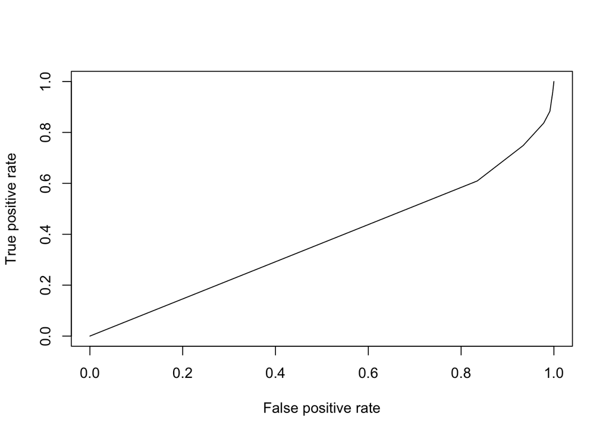

```r
plot(performance(prediction(train_data$est_prob4,train_data$pm2.5),'tpr','fpr'))
```

```r
print(paste("AUC value  for test data", round(AUC.test4, 2)))
```

```
## [1] "AUC value  for test data 0.59"
```

```r
 "AUC value  for test data 0.59"
```

```
## [1] "AUC value  for test data 0.59"
```

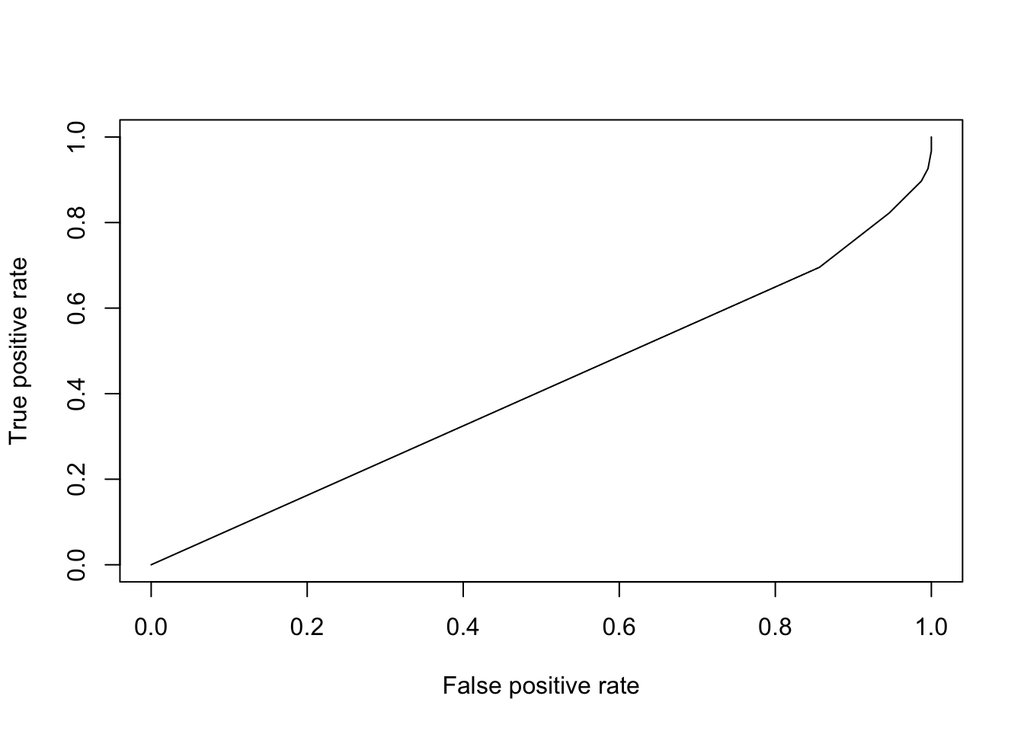

```r
plot(performance(prediction(test_data$est.prop4,test_data$pm2.5),'tpr','fpr'))
```

Lws의 AUC값은 아래와 같다.  
AUC value for train data 0.62  
AUC value for test data 0.59

4-3  
Threshold 0.5를 기준으로 train AUC가 0.62로 test AUC 0.59보다 크니까 overfitting이라고 할 수 있다.

4-4

5. time 변수를 사용해서 문제 2번의 과정을 반복해보자.  
   Time은 day와 night 으로 나눠져있다. 위와 같은 과정을 반복하기 때문에 결과값만 나타내고 나머지 과정은 echo=F로 보이지 않도록 처리하였다.

```
##
##          HIGH   LOW
##   day    5572  6833
##   night 10673 10018
```

```
##
##              HIGH       LOW
##   day   0.4491737 0.5508263
##   night 0.5158281 0.4841719
```

```
##     night       day
## 0.5158281 0.4491737
```

```
## [1] 0.53
```

```
## # A tibble: 10 x 15
##       No Month  TEMP    Iws time  pm2.5 est.prop predict TEMP_GRP est.prop2
##    <dbl> <fct> <dbl>  <dbl> <fct> <fct>    <dbl> <lgl>   <fct>        <dbl>
##  1 35065 Jan       7 143.   night LOW      0.435 FALSE   cold         0.447
##  2 35066 Jan       7 148.   night LOW      0.435 FALSE   cold         0.447
##  3 35067 Jan       6 152.   night LOW      0.435 FALSE   cold         0.447
##  4 35068 Jan       6 153.   night LOW      0.435 FALSE   cold         0.447
##  5 35069 Jan       3   0.89 night HIGH     0.435 FALSE   cold         0.447
##  6 35070 Jan       4   4.02 night HIGH     0.435 FALSE   cold         0.447
##  7 35071 Jan       6   8.94 night HIGH     0.435 FALSE   cold         0.447
##  8 35072 Jan       6  16.1  night HIGH     0.435 FALSE   cold         0.447
##  9 35073 Jan       6  21.9  night LOW      0.435 FALSE   cold         0.447
## 10 35074 Jan       7  26.8  night LOW      0.435 FALSE   cold         0.447
## # … with 5 more variables: predict2 <lgl>, Iws_GRP <fct>, est.prop4 <dbl>,
## #   predict4 <lgl>, est.prop3 <dbl>
```

```
## # A tibble: 10 x 16
##       No Month  TEMP    Iws time  pm2.5 est.prop predict TEMP_GRP est.prop2
##    <dbl> <fct> <dbl>  <dbl> <fct> <fct>    <dbl> <lgl>   <fct>        <dbl>
##  1 35065 Jan       7 143.   night LOW      0.435 FALSE   cold         0.447
##  2 35066 Jan       7 148.   night LOW      0.435 FALSE   cold         0.447
##  3 35067 Jan       6 152.   night LOW      0.435 FALSE   cold         0.447
##  4 35068 Jan       6 153.   night LOW      0.435 FALSE   cold         0.447
##  5 35069 Jan       3   0.89 night HIGH     0.435 FALSE   cold         0.447
##  6 35070 Jan       4   4.02 night HIGH     0.435 FALSE   cold         0.447
##  7 35071 Jan       6   8.94 night HIGH     0.435 FALSE   cold         0.447
##  8 35072 Jan       6  16.1  night HIGH     0.435 FALSE   cold         0.447
##  9 35073 Jan       6  21.9  night LOW      0.435 FALSE   cold         0.447
## 10 35074 Jan       7  26.8  night LOW      0.435 FALSE   cold         0.447
## # … with 6 more variables: predict2 <lgl>, Iws_GRP <fct>, est.prop4 <dbl>,
## #   predict4 <lgl>, est.prop3 <dbl>, predict3 <lgl>
```

```
##        actual
## pred    HIGH  LOW
##   FALSE 1403 1838
##   TRUE  2800 2619
```

```
## [1] 0.54
```

Time의 train accuracy3는 0.53 , accuracy_test3 : 0.54이다.

```r
#5-2
AUC.train3 <- calAUC(train_data$est_prob3, train_data$pm2.5 == "HIGH")
AUC.test3 <- calAUC(test_data$est.prop3, test_data$pm2.5 == "HIGH")

print(paste("AUC value  for train data", round(AUC.train3, 2)))
```

```
## [1] "AUC value  for train data 0.53"
```

```r
"AUC value  for train data 0.53"
```

```
## [1] "AUC value  for train data 0.53"
```

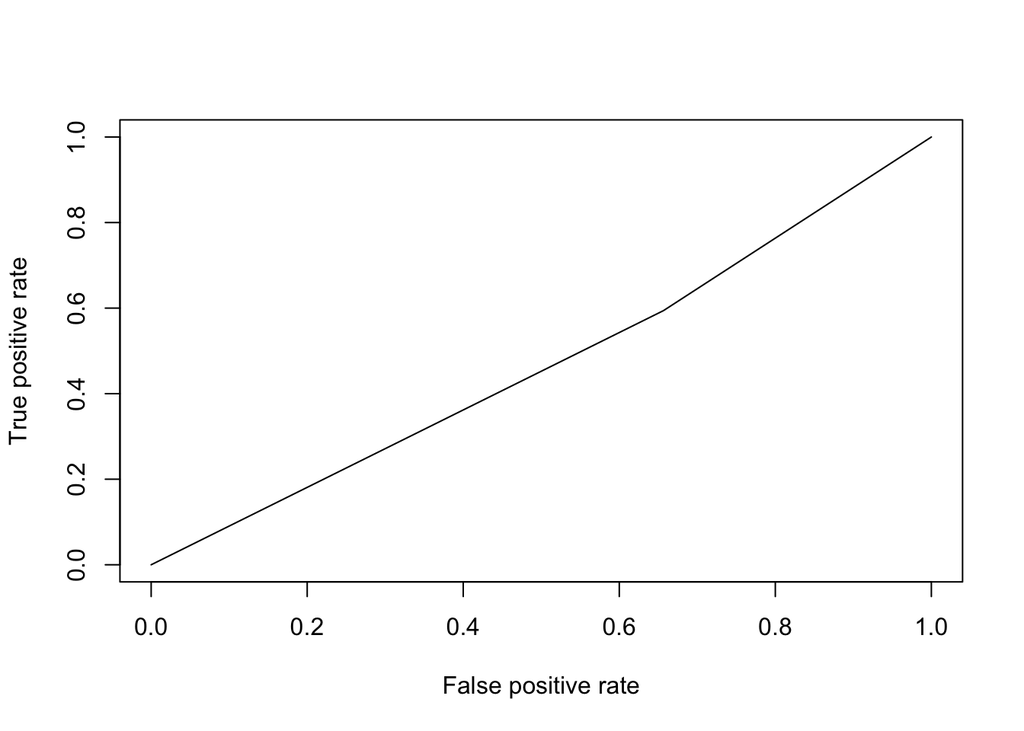

```r
plot(performance(prediction(train_data$est_prob3,train_data$pm2.5),'tpr','fpr'))
```

```r
print(paste("AUC value  for test data", round(AUC.test3, 2)))
```

```
## [1] "AUC value  for test data 0.54"
```

```r
"AUC value  for test data 0.54"
```

```
## [1] "AUC value  for test data 0.54"
```

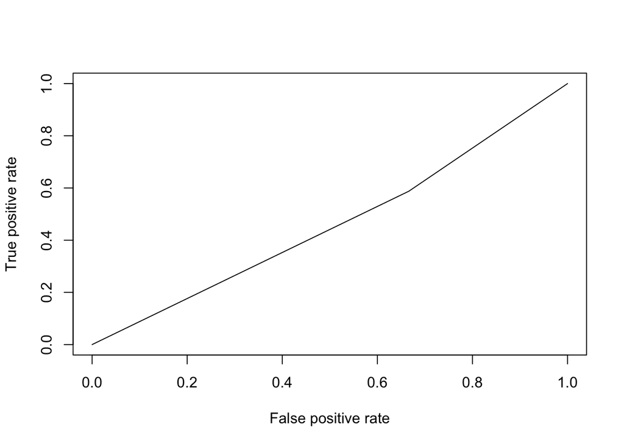

```r
plot(performance(prediction(test_data$est.prop3,test_data$pm2.5),'tpr','fpr'))
```

TIME의 AUC값은 아래와 같다.  
AUC value for train data 0.53  
AUC value for test data 0.54

5-3  
time을 기준으로 한 모델은 Threshold 0.5를 기준으로 test AUC가 0.54로 train AUC 0.53보다 크니까 overfitting이 아니라고 할 수 있다. /

```
## [1] 1.02
```

```
## # A tibble: 10 x 16
##       No Month  TEMP    Iws time  pm2.5 est.prop predict TEMP_GRP est.prop2
##    <dbl> <fct> <dbl>  <dbl> <fct> <fct>    <dbl> <lgl>   <fct>        <dbl>
##  1 35065 Jan       7 143.   night LOW      0.435 FALSE   cold         0.447
##  2 35066 Jan       7 148.   night LOW      0.435 FALSE   cold         0.447
##  3 35067 Jan       6 152.   night LOW      0.435 FALSE   cold         0.447
##  4 35068 Jan       6 153.   night LOW      0.435 FALSE   cold         0.447
##  5 35069 Jan       3   0.89 night HIGH     0.435 FALSE   cold         0.447
##  6 35070 Jan       4   4.02 night HIGH     0.435 FALSE   cold         0.447
##  7 35071 Jan       6   8.94 night HIGH     0.435 FALSE   cold         0.447
##  8 35072 Jan       6  16.1  night HIGH     0.435 FALSE   cold         0.447
##  9 35073 Jan       6  21.9  night LOW      0.435 FALSE   cold         0.447
## 10 35074 Jan       7  26.8  night LOW      0.435 FALSE   cold         0.447
## # … with 6 more variables: predict2 <lgl>, Iws_GRP <fct>, est.prop4 <dbl>,
## #   predict4 <lgl>, est.prop3 <dbl>, predict3 <lgl>
```

```
## # A tibble: 10 x 16
##       No Month  TEMP    Iws time  pm2.5 est.prop predict TEMP_GRP est.prop2
##    <dbl> <fct> <dbl>  <dbl> <fct> <fct>    <dbl> <lgl>   <fct>        <dbl>
##  1 35065 Jan       7 143.   night LOW      0.435 FALSE   cold         0.447
##  2 35066 Jan       7 148.   night LOW      0.435 FALSE   cold         0.447
##  3 35067 Jan       6 152.   night LOW      0.435 FALSE   cold         0.447
##  4 35068 Jan       6 153.   night LOW      0.435 FALSE   cold         0.447
##  5 35069 Jan       3   0.89 night HIGH     0.435 FALSE   cold         0.447
##  6 35070 Jan       4   4.02 night HIGH     0.435 FALSE   cold         0.447
##  7 35071 Jan       6   8.94 night HIGH     0.435 FALSE   cold         0.447
##  8 35072 Jan       6  16.1  night HIGH     0.435 FALSE   cold         0.447
##  9 35073 Jan       6  21.9  night LOW      0.435 FALSE   cold         0.447
## 10 35074 Jan       7  26.8  night LOW      0.435 FALSE   cold         0.447
## # … with 6 more variables: predict2 <lgl>, Iws_GRP <fct>, est.prop4 <dbl>,
## #   predict4 <lgl>, est.prop3 <dbl>, predict3 <lgl>
```

```
##        actual
## pred    HIGH  LOW
##   FALSE 4203 4457
```

```
##        actual
## pred    HIGH  LOW
##   FALSE 0.97 1.03
```

```
## [1] "AUC value  for train data 0.53"
```

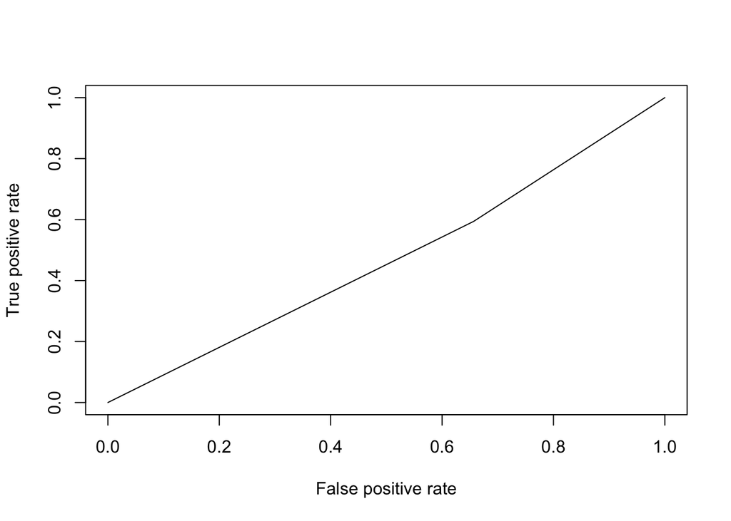

```
## [1] "AUC value  for test data 0.54"
```

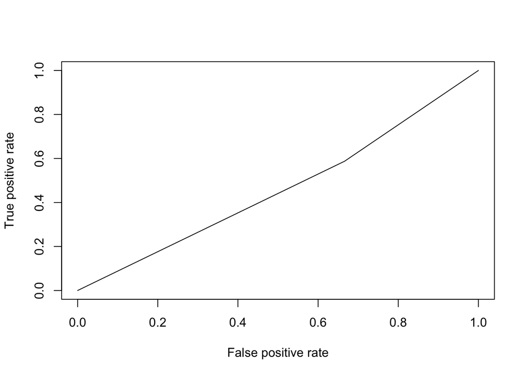

5-6  
F1값은 아래와 같이 구하고 결과값을 확인 할 수 있다.

```r
F1.train3 <- 2 * precision3 * recall3 / (precision3 + recall3)
F1.test3 <- 2 * precision.t3 * recall.t3 / (precision.t3 + recall.t3)
```

F1.train3 : 0.5779186 F1.test3 : 0.5819996